# Lab 5: Central Limit Theorem

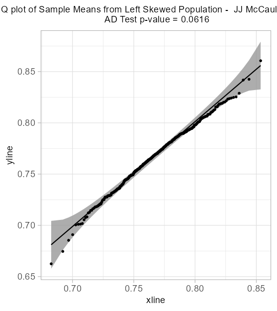

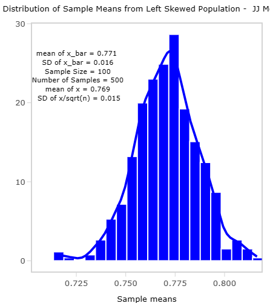

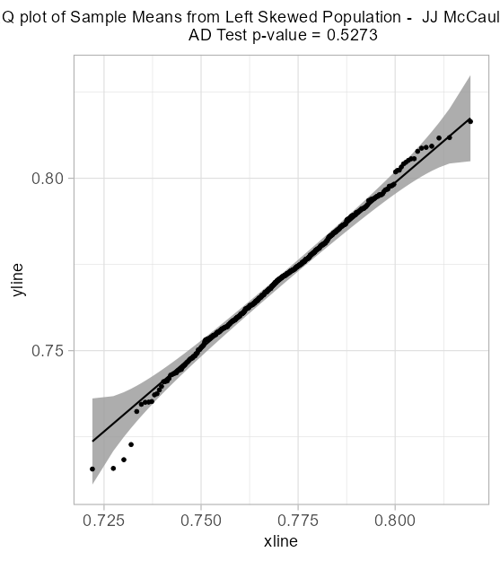

[output not shown]

Population Distribution

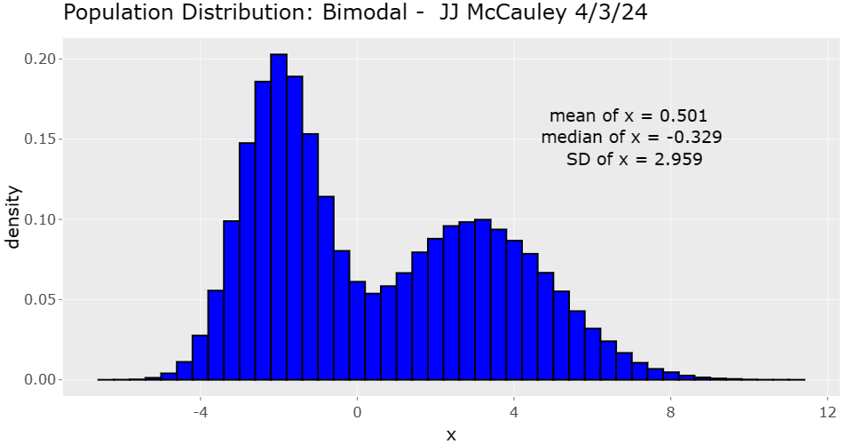

Bimodal

Sampling Distribution

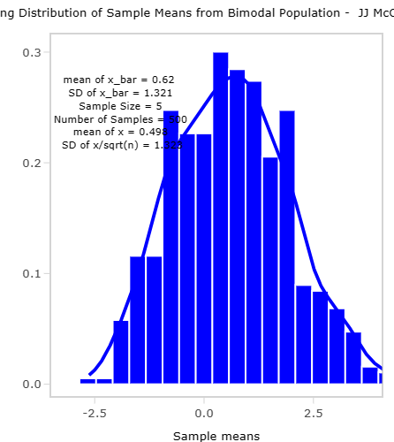

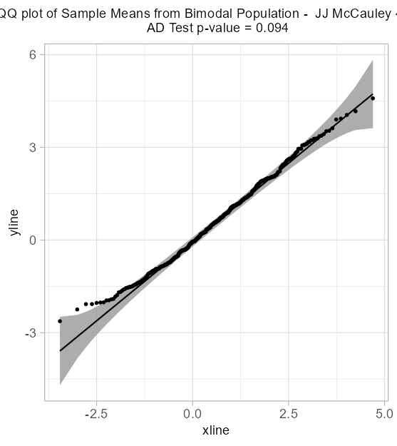

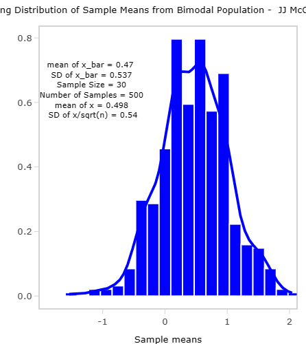

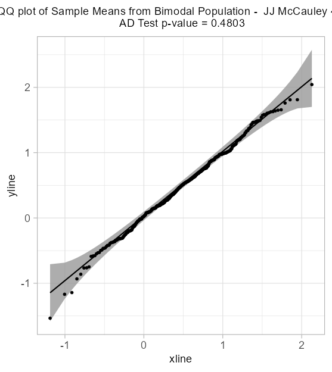

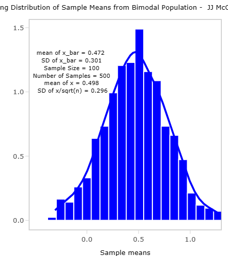

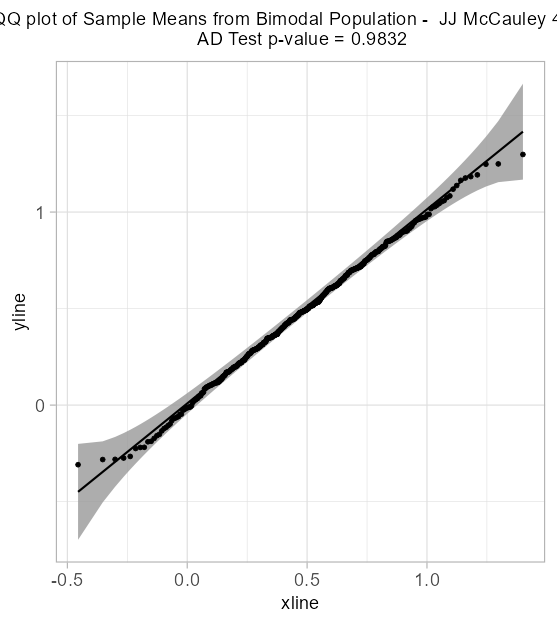

**End of Assignment 3**

# Part III: Sampling Distributions of Sample Means: When Assumptions are NOT Satisfied

In part II, the “parent” distributions we selected in fact satisfied the assumptions needed for the Central Limit Theorem. But what if one or some of the assumptions are not satisfied? Will the Central Limit Theorem still hold? Let’s consider a particular distribution: **Cauchy Distribution**.

One interesting facts about Cauchy distribution is that, it does NOT have defined mean or standard deviation, thus assumptions 1 and 2 are not satisfied. Let’s explore the properties of the sampling distribution of sample means by completing the following assignment.

## Assignment 4

Set the Population Distribution to “Cauchy”. Then Answer all questions in Assignment 2

[output not shown]

Population Distribution

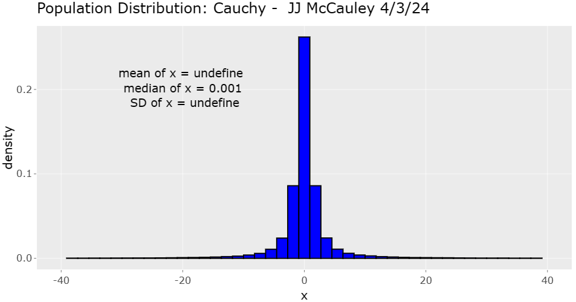

Cauchy

Sampling Distribution

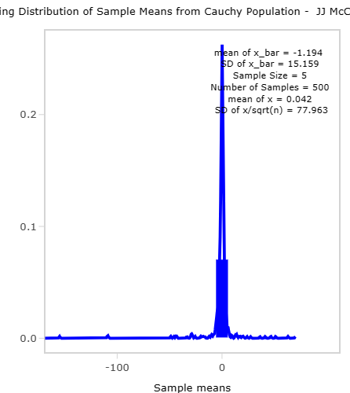

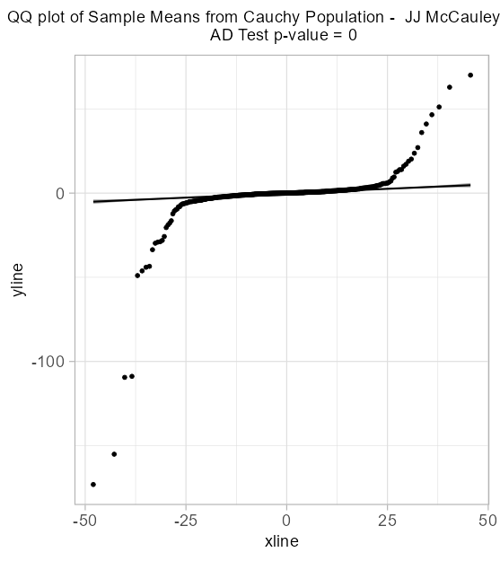

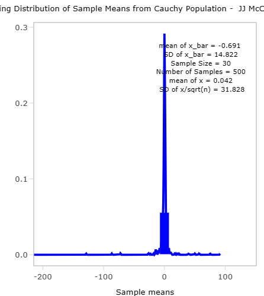

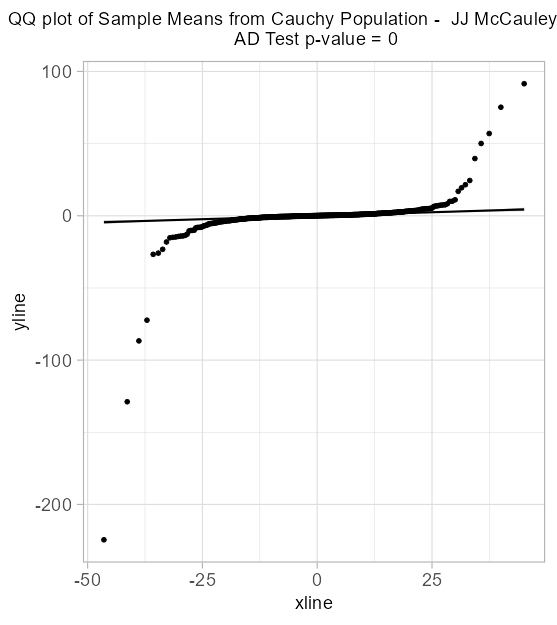

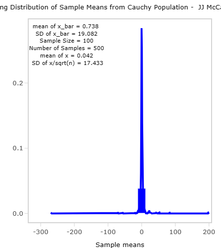

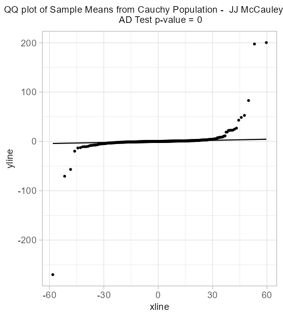

**End of Assignment 4**

So, what can we do when assumption 1 and/or 2 are not satisfied? Interestingly, we can have a “Central Limit Theorem” for **Sample Medians** (we are dealing with sample means only by far). Of course, the sample medians version CLT also require OTHER assumptions. We don’t go into the details here, but for the case of Cauchy, we can say the assumptions are satisfied. In this version, the mean of the sampling distribution of the sample medians is the population median, and the standard deviation is proportional to $1/\sqrt{n}$.

## Assignment 5

1. Go to the tab “Sampling Distribution - Sample Median”
2. Set the Population Distribution as “Cauchy”, Number of samples as 500, then change sample size as 10, 50, 100, and 300 respectively.
3. For each selected sample size, download the histogram and QQ-plot, then insert below.

Samples:

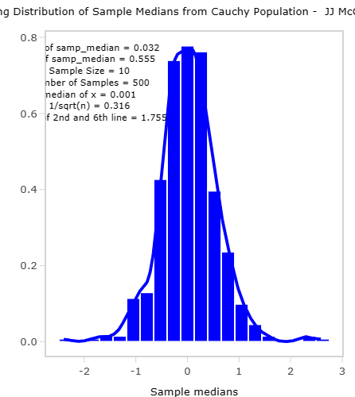

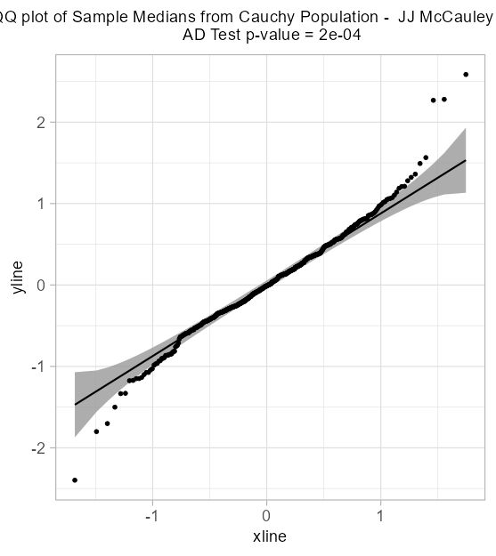

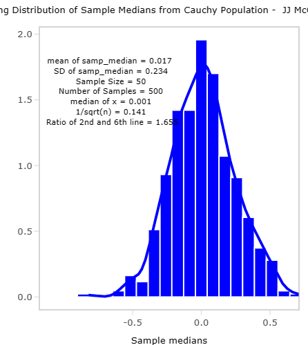

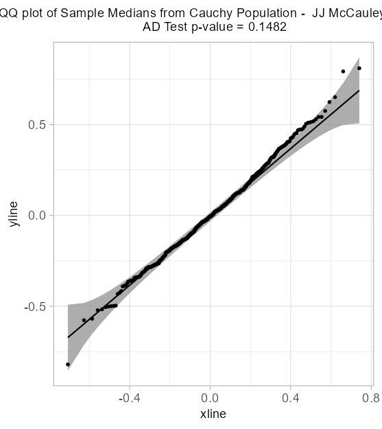

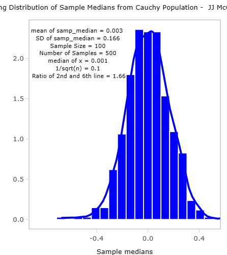

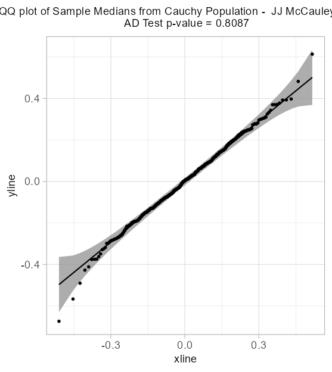

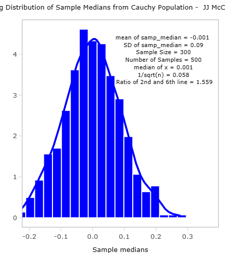

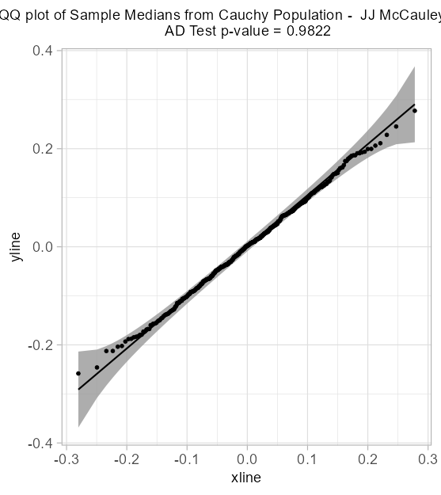

4. For each selected sample size, compare the “mean of samp_median” and “median of x” on the histogram. Then check if the “Ratio of 2nd and 6th line” are approximately equal to each others for different sample size. What is your observations.

   ```
   When the sample size is 10, the mean of samp_median is .032 while the median of x is .001, which is dissimular. The ratio of 2nd and 6th line is 1.755.
   When the sample size is 50, the mean of samp_median is .017 while the median of x is .001, which is somewhat similar. The ratio of 2nd and 6th line is 1.655.
   When the sample size is 100, the mean of samp_median is .003 while the median of x is .001, This is fairly similar. The ratio of 2nd and 6th line is 1.66.
   When the sample size is 300, the mean of samp_median is -.001 while the median of x is .001, which is similar. The ratio of 2nd and 6th line is 1.559.

   As the sample sizes increased, the gaps between the mean of samp_median and the median of x were reduced immensely. Additionally, the Ratio of 2nd and 6th line stayed approximately the same throughout the different samples, slowly decreasing as the sample sizes got larger.
   ```

5. For each selected sample size, is the sampling distribution of sample median approximately normal? How does the sample size increasing affect the normality approaching?

**End of Assignment 5**

# Part IV: Knit this markdown file to a html report

After you complete all the above assignments, click the Knit button to create a html report. Submit that html report.